# Understanding Social Dynamics in an Elevator Setting

## What’s going on with the data?

This dataset captures the details of everyday elevator rides-how crowded they were, the time of day, and whether people chatted or kept to themselves. By tracking these moments, we can spot patterns in elevator use and social behaviour as people move through the building.

This project uses observational data collection to investigate the social dynamics of elevator rides. Building on Project 2’s work, this project uses more data and visual storytelling techniques to continue analysis.

## Number of Elevator Rides by Time of Day

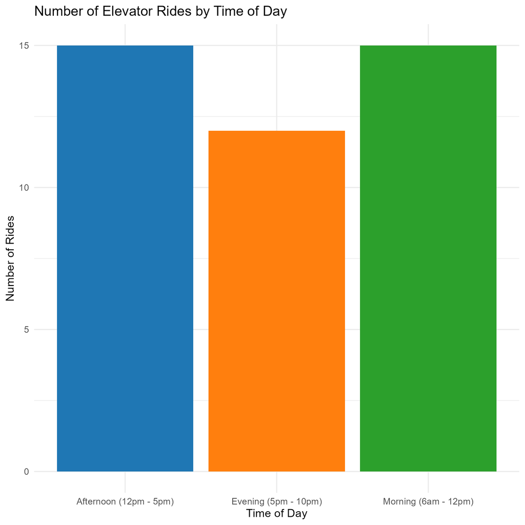

According to data, the morning and afternoon hours see the highest number of elevator rides (15 rides each). In contrast, there are fewer rides in the evening. This implies that elevator use is highly correlated with regular work or school schedules.

## Conversation Likelihood by Elevator Busyness

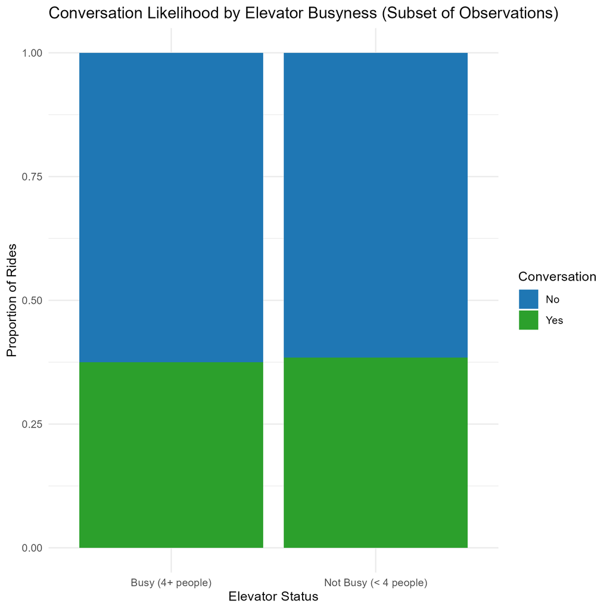

Stacked bar chart showing proportions of conversations in busy vs. not-busy elevators.

I looked at the observations where conversation was noted to see if people conversed during the ride. Regardless of whether the elevator was crowded (four or more people) or not (fewer than four), the plot indicates that conversation is not so common, with little difference between < 4 people and > 4 people. This suggests that regardless of the crowd size, conversation does not typically happen in an enclosed public space.

## Elevator Usage Throughout the Day

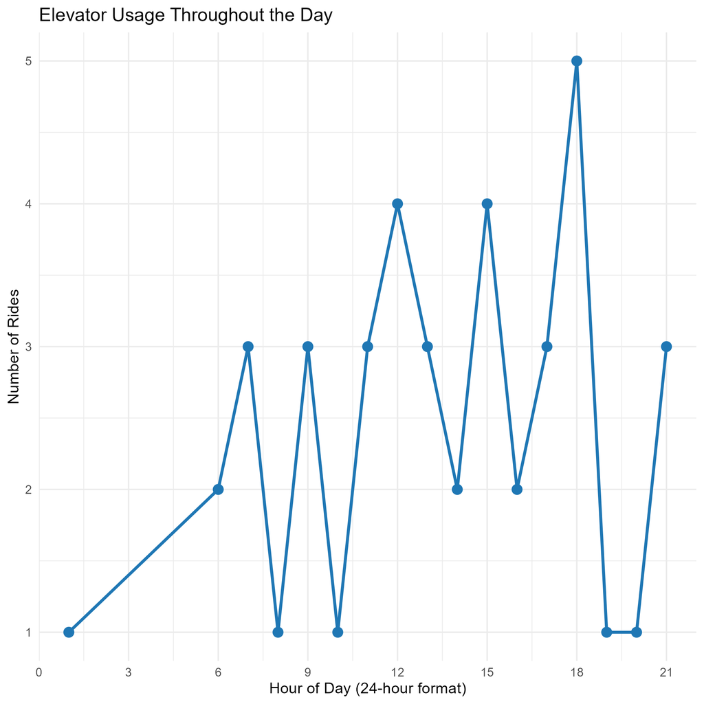

Line graph showing elevator ride frequency per hour, with peaks around midday and late afternoon.

There are clear peaks throughout the day, with the highest activity occurring around lunchtime and in the late afternoon. This pattern further supports the idea that elevator demand aligns with common work or class transitions, breaks, and end-of-day departures.

## Top 5 Most Crowded Rides

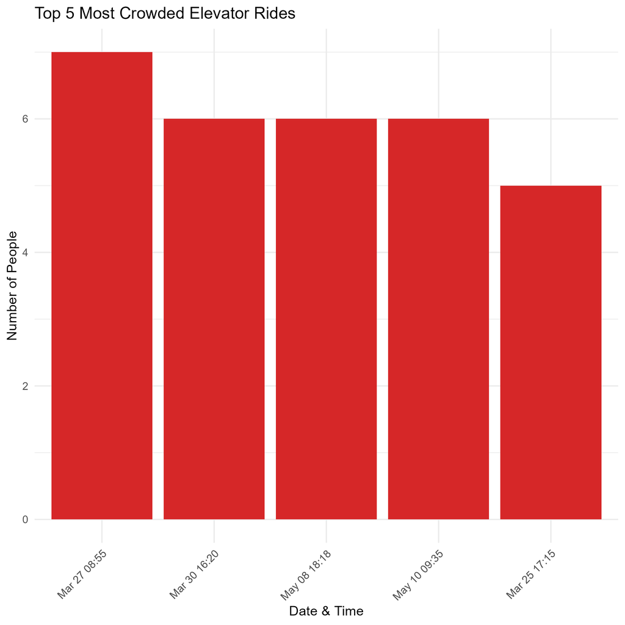

Bar chart of the 5 most crowded elevator rides with timestamps.

I identified the top five most crowded elevator rides in the dataset. The most crowded ride had 7 people, with several others at 6. These crowded rides occurred at various times and dates, indicating that a high crowd size is not constant can happen at different points in the week.

## Final Thoughts

This analysis highlights distinct patterns in elevator usage and social behaviour. Most rides occur during traditional busy periods in the morning and afternoon, and conversation is relatively rare, even in crowded conditions. These findings suggest that elevator rides in this setting tend to be a functional need to help with daily routines